# Spatial Prediction of Burglaries with 311 Graffiti Removal Requests

# Part 3: Create Spatial Predictor Variables

## 3.1: Count of Graffiti Removal per Cell

```r
Removal_fishnet <- st_join(fishnet, Graffiti_removal, join = st_contains) %>%
  st_drop_geometry() %>%
  count(uniqueID, name = "Graffiti_removal")

fishnet$Graffiti_removal <- 0L

idx <- match(Removal_fishnet$uniqueID, fishnet$uniqueID)
fishnet$Graffiti_removal[idx] <- Removal_fishnet$Graffiti_removal

fishnet %>%
  st_drop_geometry() %>%
  summarize(
    Min = min(Graffiti_removal),
    Q1 = quantile(Graffiti_removal, 0.25),
    Median = median(Graffiti_removal),
    Mean = mean(Graffiti_removal),
    Q3 = quantile(Graffiti_removal, 0.75),
    Max = max(Graffiti_removal)
  ) %>%
  mutate(across(everything(), ~round(., 2))) %>%
  kable(
    caption = "Summary of Graffiti Removal 311 Calls per 500m Grid Cell"
  ) %>%
  kable_styling(bootstrap_options = c("striped", "hover"))
```

Summary of Graffiti Removal 311 Calls per 500m Grid Cell

| Min | Q1 | Median | Mean | Q3 | Max |
| --- | --- | --- | --- | --- | --- |
| 1 | 16 | 80 | 427.82 | 487.75 | 7590 |

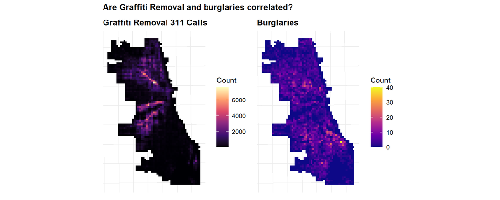

```r
p1 <- ggplot() +
  geom_sf(data = fishnet, aes(fill = Graffiti_removal), color = NA) +
  scale_fill_viridis_c(name = "Count", option = "magma") +
  labs(title = "Graffiti Removal 311 Calls") +
  theme_crime()

p2 <- ggplot() +
  geom_sf(data = fishnet, aes(fill = countBurglaries), color = NA) +
  scale_fill_viridis_c(name = "Count", option = "plasma") +
  labs(title = "Burglaries") +
  theme_crime()

p1 + p2 +
  plot_annotation(title = "Are Graffiti Removal and burglaries correlated?")
```

Visually, the two patterns do not align very closely. Graffiti Removal calls are concentrated in a few very specific pockets, mainly in the Northwest and parts of the West and Southwest sides. Burglary, however, is more broadly distributed, with multiple hotspots across the West Side, South Side, and the central areas of the city.

There is some general overlap in higher-activity regions, but the intensity and location of clusters differ enough that graffiti does not appear to be a consistent indicator of burglary risk. Graffiti reflects surface-level disorder in public space, while burglary involves private property intrusion, which likely responds to different environmental and situational factors.

## 3.2: Nearest Neighbor Features

```r
# Calculate mean distance to 3 nearest Graffiti Removal
Graffiti_clean <- Graffiti_removal %>%
  filter(!st_is_empty(geometry))

# Get coordinates
fishnet_coords <- st_coordinates(st_centroid(fishnet))
removal_coords <- st_coordinates(Graffiti_clean)

# Calculate k nearest neighbors and distances
nn_result <- get.knnx(removal_coords, fishnet_coords, k = 3)

# Add to fishnet
fishnet <- fishnet %>%
  mutate(
    Graffiti_clean.nn = rowMeans(nn_result$nn.dist)
  )

fishnet %>%
  st_drop_geometry() %>%
  summarize(
    Min = min(Graffiti_clean.nn),
    Q1 = quantile(Graffiti_clean.nn, 0.25),
    Median = median(Graffiti_clean.nn),
    Mean = mean(Graffiti_clean.nn),
    Q3 = quantile(Graffiti_clean.nn, 0.75),
    Max = max(Graffiti_clean.nn)
  ) %>%
  mutate(across(everything(), ~round(., 2))) %>%
  kable(
    caption = "Summary of Mean Distance to 3 Nearest Graffiti Removal Calls (meters)"
  ) %>%
  kable_styling(bootstrap_options = c("striped", "hover"))
```

Summary of Mean Distance to 3 Nearest Graffiti Removal Calls (meters)

| Min | Q1 | Median | Mean | Q3 | Max |
| --- | --- | --- | --- | --- | --- |
| 0.55 | 28.61 | 60.28 | 135.14 | 137.95 | 1476.26 |

The distance-to-graffiti feature shows substantial variation, with a median of ~60 m but a long tail up to 1.4 km. This indicates that some neighborhoods are very close to multiple graffiti complaints, while others are far removed. This spatial heterogeneity helps capture environmental disorder that may relate to burglary risk.

## 3.3: Distance to Hot Spots

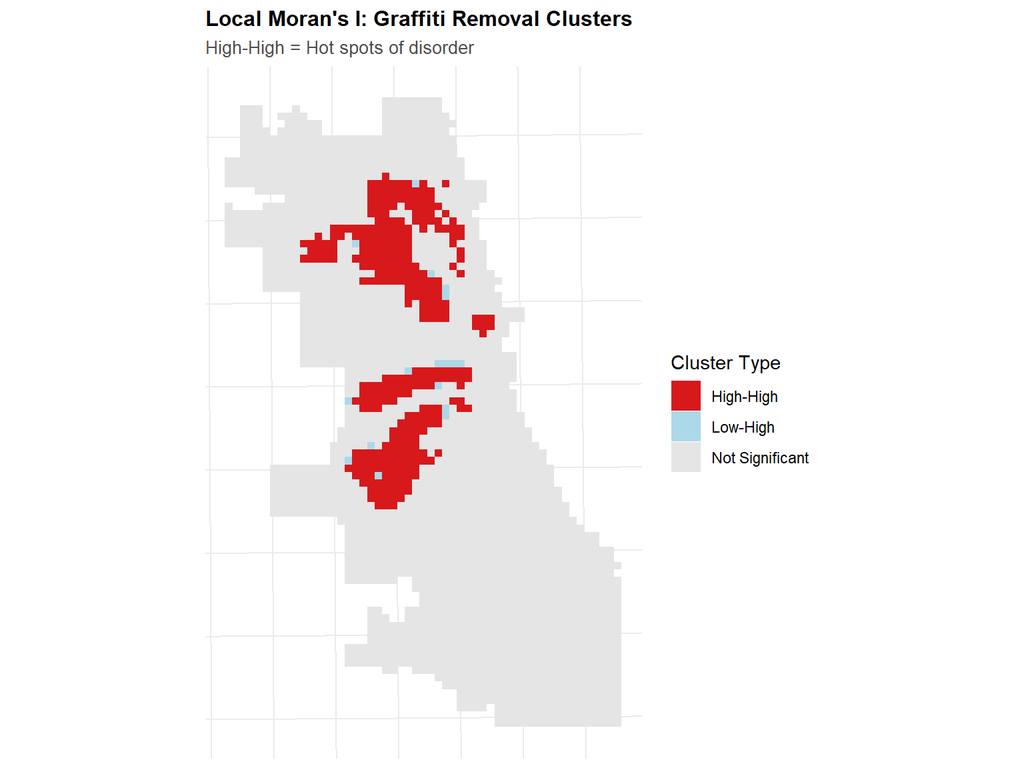

```r
# Visualize hot spots
ggplot() +
  geom_sf(
    data = fishnet,
    aes(fill = moran_class),
    color = NA
  ) +
  scale_fill_manual(
    values = c(
      "High-High" = "#d7191c",
      "High-Low" = "#fdae61",
      "Low-High" = "#abd9e9",
      "Low-Low" = "#2c7bb6",
      "Not Significant" = "gray90"
    ),
    name = "Cluster Type"
  ) +
  labs(
    title = "Local Moran's I: Graffiti Removal Clusters",
    subtitle = "High-High = Hot spots of disorder"
  ) +
  theme_crime()
```

Distance to a cluster of Graffiti Removal calls is more informative than distance to a single graffiti incident because it captures the broader neighborhood context of disorder. A single report might be noisy or idiosyncratic, but a High–High cluster from Local Moran’s I represents an area where both the cell and its neighbors have consistently high graffiti counts. Being close to such a cluster suggests that a grid cell lies within or near a larger zone of visible deterioration or neglect.

# Part 4: Model Fitting

## 4.1: Poisson Regression

```r
# Fit Poisson regression
library(broom)

model_poisson <- glm(
  countBurglaries ~ Graffiti_removal + Graffiti_clean.nn +
    dist_to_hotspot,
  data = fishnet_model,
  family = "poisson"
)

poisson_tbl <- tidy(model_poisson) %>%
  mutate(
    estimate = round(estimate, 4),
    std.error = round(std.error, 4),
    statistic = round(statistic, 2),
    p.value = round(p.value, 4)
  )

kable(
  poisson_tbl,
  caption = "Poisson Regression Results"
) %>%
  kable_styling(bootstrap_options = c("striped", "hover"))
```

Poisson Regression Results

| term | estimate | std.error | statistic | p.value |
| --- | --- | --- | --- | --- |
| (Intercept) | 1.5900 | 0.0260 | 61.15 | 0.0000 |
| Graffiti_removal | 0.0001 | 0.0000 | 4.74 | 0.0000 |
| Graffiti_clean.nn | -0.0063 | 0.0003 | -22.46 | 0.0000 |
| dist_to_hotspot | 0.0000 | 0.0000 | 3.76 | 0.0002 |

**All three predictors are statistically significant (p < 0.001).**

1. **Graffiti_removal** has a *positive* association with burglary counts.

```
More graffiti complaints → slightly more burglaries.
```

2. **Graffiti_clean.nn** has a *strong negative* association.

   Cells closer to graffiti activity → much higher burglary risk.

   This is the strongest predictor in the model.
3. **dist_to_hotspot** has a very weak but statistically significant *positive* association.

   Being farther from graffiti hotspots slightly increases predicted burglaries.

   Effect size is tiny and may not be meaningful.

## 4.2: Negative Binomial Regression

If overdispersed, use **Negative Binomial regression** (more flexible).

```r
# Fit Negative Binomial model
model_nb <- glm.nb(
  countBurglaries ~ Graffiti_removal + Graffiti_clean.nn +
    dist_to_hotspot,
  data = fishnet_model
)

nb_tbl <- tidy(model_nb) %>%
  mutate(
    estimate = round(estimate, 4),
    std.error = round(std.error, 4),
    statistic = round(statistic, 2),
    p.value = round(p.value, 4)
  )

kable(
  nb_tbl,
  caption = "Negative Binomial Regression Results"
) %>%
  kable_styling(bootstrap_options = c("striped", "hover"))
```

Negative Binomial Regression Results

| term | estimate | std.error | statistic | p.value |
| --- | --- | --- | --- | --- |
| (Intercept) | 1.6604 | 0.0497 | 33.38 | 0.0000 |
| Graffiti_removal | 0.0001 | 0.0000 | 1.55 | 0.1211 |
| Graffiti_clean.nn | -0.0079 | 0.0005 | -17.15 | 0.0000 |
| dist_to_hotspot | 0.0000 | 0.0000 | 3.34 | 0.0008 |

# Part 5: Spatial Cross-Validation

```r
# Show results
cv_results %>%
  arrange(desc(mae)) %>%
  kable(
    digits = 2,
    caption = "LOGO CV Results by District"
  ) %>%
  kable_styling(bootstrap_options = c("striped", "hover"))
```

LOGO CV Results by District

| fold | test_district | n_test | mae | rmse |
| --- | --- | --- | --- | --- |
| 7 | 3 | 43 | 6.31 | 8.42 |
| 4 | 6 | 63 | 3.87 | 5.35 |
| 12 | 12 | 73 | 3.44 | 4.63 |
| 2 | 4 | 235 | 3.38 | 5.45 |
| 6 | 7 | 52 | 3.38 | 4.23 |
| 14 | 11 | 43 | 3.12 | 4.02 |
| 15 | 18 | 30 | 2.73 | 3.85 |
| 5 | 8 | 197 | 2.72 | 3.72 |
| 10 | 10 | 63 | 2.62 | 3.44 |
| 21 | 20 | 30 | 2.58 | 2.98 |
| 17 | 14 | 46 | 2.57 | 3.86 |
| 8 | 2 | 56 | 2.55 | 3.41 |
| 16 | 25 | 85 | 2.54 | 3.46 |
| 9 | 9 | 107 | 2.46 | 2.86 |
| 11 | 1 | 28 | 2.44 | 2.93 |
| 19 | 16 | 129 | 2.36 | 2.76 |
| 22 | 24 | 41 | 2.35 | 2.64 |
| 13 | 15 | 32 | 2.32 | 2.96 |
| 3 | 22 | 112 | 2.17 | 2.76 |
| 20 | 17 | 82 | 2.14 | 2.48 |
| 1 | 5 | 98 | 1.92 | 2.87 |
| 18 | 19 | 63 | 1.91 | 2.34 |

Spatial CV is more appropriate than random CV because crime data is highly spatially autocorrelated. Random CV would mix neighboring cells into both training and testing sets, causing spatial leakage and artificially inflating model performance. LOGO CV avoids this by holding out entire police districts, which tests the model’s ability to generalize to new spatial areas.

From the results, District 3 was the hardest to predict (MAE = 6.31), followed by District 6, suggesting that these areas have unique burglary patterns not well explained by graffiti-based predictors. In contrast, District 19 was one of the easiest districts to predict (MAE ≈ 1.9), indicating burglary patterns there are more stable and similar to the training data.

# Part 6: Model Evaluation

## 6.1: Compare Model vs. KDE Baseline

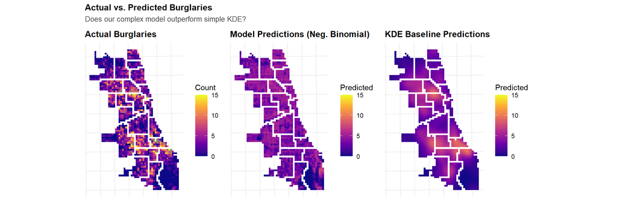

```r
# Create three maps
p1 <- ggplot() +
  geom_sf(data = fishnet, aes(fill = countBurglaries), color = NA) +
  scale_fill_viridis_c(name = "Count", option = "plasma", limits = c(0, 15)) +
  labs(title = "Actual Burglaries") +
  theme_crime()

p2 <- ggplot() +
  geom_sf(data = fishnet, aes(fill = prediction_nb), color = NA) +
  scale_fill_viridis_c(name = "Predicted", option = "plasma", limits = c(0, 15)) +
  labs(title = "Model Predictions (Neg. Binomial)") +
  theme_crime()

p3 <- ggplot() +
  geom_sf(data = fishnet, aes(fill = prediction_kde), color = NA) +
  scale_fill_viridis_c(name = "Predicted", option = "plasma", limits = c(0, 15)) +
  labs(title = "KDE Baseline Predictions") +
  theme_crime()

p1 + p2 + p3 +
  plot_annotation(
    title = "Actual vs. Predicted Burglaries",
    subtitle = "Does our complex model outperform simple KDE?"
  )
```

```r
# Calculate performance metrics
comparison <- fishnet %>%
  st_drop_geometry() %>%
  filter(!is.na(prediction_nb), !is.na(prediction_kde)) %>%
  summarize(
    model_mae = mean(abs(countBurglaries - prediction_nb)),
    model_rmse = sqrt(mean((countBurglaries - prediction_nb)^2)),
    kde_mae = mean(abs(countBurglaries - prediction_kde)),
    kde_rmse = sqrt(mean((countBurglaries - prediction_kde)^2))
  )

comparison %>%
  pivot_longer(everything(), names_to = "metric", values_to = "value") %>%
  separate(metric, into = c("approach", "metric"), sep = "_") %>%
  pivot_wider(names_from = metric, values_from = value) %>%
  kable(
    digits = 2,
    caption = "Model Performance Comparison"
  ) %>%
  kable_styling(bootstrap_options = c("striped", "hover"))
```

Model Performance Comparison

| approach | mae | rmse |
| --- | --- | --- |
| model | 2.56 | 3.66 |
| kde | 2.06 | 2.95 |

### **The KDE baseline performs better than the complex model**

The KDE has **lower MAE and RMSE**, which means:

- Smaller average prediction error
- More stable predictions
- Better overall fit to the spatial pattern of burglaries

This is a common result in spatial prediction tasks: KDE is extremely strong because crime tends to cluster, and KDE captures clustering very well without requiring any assumptions or regression structure.

## 6.2: Where Does the Model Work Well?

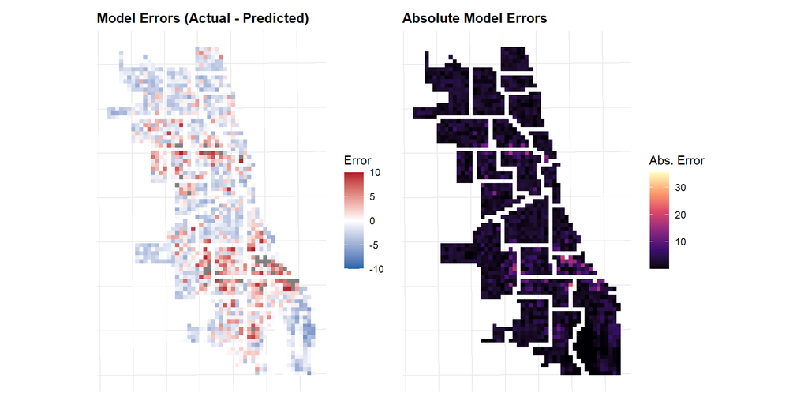

```r
# Calculate errors
fishnet <- fishnet %>%
  mutate(
    error_nb = countBurglaries - prediction_nb,
    error_kde = countBurglaries - prediction_kde,
    abs_error_nb = abs(error_nb),
    abs_error_kde = abs(error_kde)
  )

# Map errors
p1 <- ggplot() +
  geom_sf(data = fishnet, aes(fill = error_nb), color = NA) +
  scale_fill_gradient2(
    name = "Error",
    low = "#2166ac", mid = "white", high = "#b2182b",
    midpoint = 0,
    limits = c(-10, 10)
  ) +
  labs(title = "Model Errors (Actual - Predicted)") +
  theme_crime()

p2 <- ggplot() +
  geom_sf(data = fishnet, aes(fill = abs_error_nb), color = NA) +
  scale_fill_viridis_c(name = "Abs. Error", option = "magma") +
  labs(title = "Absolute Model Errors") +
  theme_crime()

p1 + p2
```

The error maps show that the Negative Binomial model systematically underpredicts burglaries in major hotspot areas especially in the South and West Sides, while slightly overpredicting in low-crime neighborhoods. This pattern suggests that the model cannot fully capture sharp, localized spikes in burglary activity, likely because graffiti-related predictors only partially reflect the underlying opportunity structures of crime. As a result, absolute errors are largest in high-crime districts and much smaller in low-crime ones, indicating that the model performs unevenly across space and is least accurate exactly where prediction is most important.

## 6.3: Model Summary Table

```r
# Create nice summary table
model_summary <- broom::tidy(final_model, exponentiate = TRUE) %>%
  mutate(
    across(where(is.numeric), ~round(., 3))
  )

model_summary %>%
  kable(
    caption = "Final Negative Binomial Model Coefficients (Exponentiated)",
    col.names = c("Variable", "Rate Ratio", "Std. Error", "Z", "P-Value")
  ) %>%
  kable_styling(bootstrap_options = c("striped", "hover")) %>%
  footnote(
    general = "Rate ratios > 1 indicate positive association with burglary counts."
  )
```

Final Negative Binomial Model Coefficients (Exponentiated)

| Variable | Rate Ratio | Std. Error | Z | P-Value |
| --- | --- | --- | --- | --- |
| (Intercept) | 5.261 | 0.05 | 33.376 | 0.000 |
| Graffiti_removal | 1.000 | 0.00 | 1.550 | 0.121 |
| Graffiti_clean.nn | 0.992 | 0.00 | -17.147 | 0.000 |
| dist_to_hotspot | 1.000 | 0.00 | 3.343 | 0.001 |

Note:  
Rate ratios > 1 indicate positive association with burglary counts.

## 6.4 Key Findings Summary

The KDE baseline clearly outperforms the regression model in both MAE and RMSE, reinforcing that burglary exhibits strong spatial clustering that is better captured through spatial density patterns than through indirect disorder indicators.

Error maps also show that the model consistently underpredicts major hotspot areas and performs best in low-crime neighborhoods, suggesting that graffiti reflects general urban conditions but does not directly track burglary risk.

In short, disorder signals like graffiti may help describe neighborhood environments, but they are not sufficient for accurately predicting burglary patterns on their own. This might because Graffiti Removal 311 calls reflect residents’ reporting behavior more than actual vandalism. High-income neighborhoods tend to overreport, while disadvantaged neighborhoods underreport, producing a spatial pattern that diverges from the true distribution of disorder and therefore has limited predictive value for burglary.